# Diabetes Prevelance by Country, Sex and Year

Alana Dabelstein 33373973

2023-05-22

# 1 Research Question

The aim of this analysis is to investigate diabetes prevalence over time. The analysis looks at the variables year, country and sex to identify groups with high diabetes prevalence.

# 2 Dataset Introduction

The dataset [‘DIABETES evolution of diabetes over time’](https://www.ncdrisc.org/data-downloads-diabetes.html) is a global dataset of diabetes prevelance from the years 1980 to 2014 and contains a total of 14,000 observations and 7 variables:

- “Country/Region/World”,
  - *e.g. “Turkey”, “Bangladesh”, “New Zealand”*
- “ISO”,
  - *A region code for international standard denominations for country subdivisions*
- “Sex”,
  - *Two factor variable “Men” or “Women”*
- “Year”,
  - *Ranges from 1980 to 2014*
- “Age-standardised diabetes prevalence”,
  - *Calculated as a percentage*
- “Lower 95% uncertainty interval” and
- “Upper 95% uncertainty interval”.

**Table 2.1** below shows the first six observations of the full dataset.

```r
# Read in Data
data_full <- read_csv("Data/Diabetes_data.csv")

# create variable for first observations
data_full_head <- head(data_full)

# display in table
kable(data_full_head,
             caption = "First Six Observations of the Full Diabetes Dataset",
             digits = 2)
```

Table 2.1: First Six Observations of the Full Diabetes Dataset

| Country/Region/World | ISO | Sex | Year | Age-standardised diabetes prevalence | Lower 95% uncertainty interval | Upper 95% uncertainty interval |
| --- | --- | --- | --- | --- | --- | --- |
| Afghanistan | AFG | Men | 1980 | 0.04 | 0.02 | 0.09 |
| Afghanistan | AFG | Men | 1981 | 0.05 | 0.02 | 0.09 |
| Afghanistan | AFG | Men | 1982 | 0.05 | 0.02 | 0.09 |
| Afghanistan | AFG | Men | 1983 | 0.05 | 0.02 | 0.09 |
| Afghanistan | AFG | Men | 1984 | 0.05 | 0.02 | 0.09 |
| Afghanistan | AFG | Men | 1985 | 0.05 | 0.02 | 0.09 |

# 3 Dataset Description

The full dataset was reduced to **1000** observations through a random generation of row numbers. The variable “ISO” was removed as it was not necessary for analysis. The reduced data has 6 variables (*Although the limit is 5 variables, I considered the lower and upper 95% confidence interval variables as one variable*). **Figure 3.1** below shows the code used to tidy the full dataset into the reduced dataset.

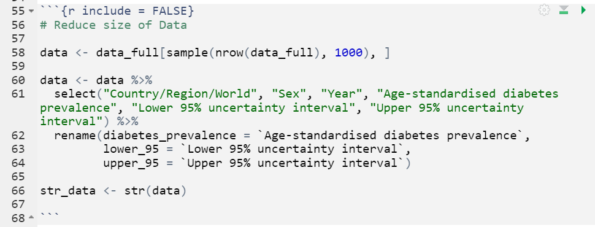

Figure 3.1: Code Screenshot of Data Tidying

```r
include_graphics("Image/code_screenshot.png")
```

Using the function **str()** the first 2 rows of the data is displayed to show the type of variables in the data set (numeric, character/factor etc.).

```r
# first display only first 2 rows
head_data_2 <- head(data,2)

str(head_data_2)
```

```
## tibble [2 × 6] (S3: tbl_df/tbl/data.frame)
##  $ Country/Region/World: chr [1:2] "Greece" "Greenland"
##  $ Sex                 : chr [1:2] "Men" "Men"
##  $ Year                : num [1:2] 1992 2005
##  $ diabetes_prevalence : num [1:2] 0.0583 0.0556
##  $ lower_95            : num [1:2] 0.0357 0.0389
##  $ upper_95            : num [1:2] 0.0884 0.0755
```

# 4 Data Summary

Mean, median, standard deviation and the maximum/minimum were calculated for diabetes prevalence by “Year”. **Table 4.1** shows the results of the summary statistics. *This section requires grouping by a factor/character variable. ‘Year’ is a numerical variable but was chosen here to better reflect the research question*.

```r
# group data by year and create summary statistics
data_summary <- data %>%
  group_by(Year) %>%
  summarise(mean_diabetes = mean(diabetes_prevalence),
            median_diabetes = median(diabetes_prevalence),
            sd_diabetes = sd(diabetes_prevalence),
            max_diabetes = max(diabetes_prevalence),
            min_diabetes = min(diabetes_prevalence))
```

```r
# display only 10 observations (latest years)
tail_data_summary <- tail(data_summary, 10)

# create table
kable(tail_data_summary,
             caption = "Mean and Standard Deviation of Diabetes Prevalence by Year (First 10 Rows)",
             digits = 3,
      row_number(10))
```

| Year | mean_diabetes | median_diabetes | sd_diabetes | max_diabetes | min_diabetes |
| --- | --- | --- | --- | --- | --- |
| 2005 | 0.110 | 0.098 | 0.054 | 0.225 | 0.045 |
| 2006 | 0.090 | 0.077 | 0.052 | 0.312 | 0.033 |
| 2007 | 0.101 | 0.081 | 0.053 | 0.267 | 0.037 |
| 2008 | 0.096 | 0.076 | 0.055 | 0.312 | 0.040 |
| 2009 | 0.095 | 0.085 | 0.043 | 0.205 | 0.044 |
| 2010 | 0.095 | 0.083 | 0.044 | 0.229 | 0.039 |
| 2011 | 0.115 | 0.090 | 0.064 | 0.254 | 0.038 |
| 2012 | 0.095 | 0.074 | 0.056 | 0.283 | 0.039 |
| 2013 | 0.102 | 0.088 | 0.049 | 0.258 | 0.042 |
| 2014 | 0.087 | 0.079 | 0.033 | 0.160 | 0.032 |

From **Table 4.1** there does not appear to be a trend in mean diabetes prevalence from 2005 to 2014. **2011 had the highest mean** diabetes prevalence at 11.5% from the period 2005 to 2014, but also the **highest standard deviation**. The maximum global diabetes prevalence was recorded in 2006 and 2008 at 31.2%. The lowest minimum was recorded in 2014 at 3.2%.

# 5 Visualisations

## 5.1 Diabetes Prevalence Over Time

A figure was created using the ggplot2 R package and the option geom_point(). This is displayed in **Figure 5.1:**

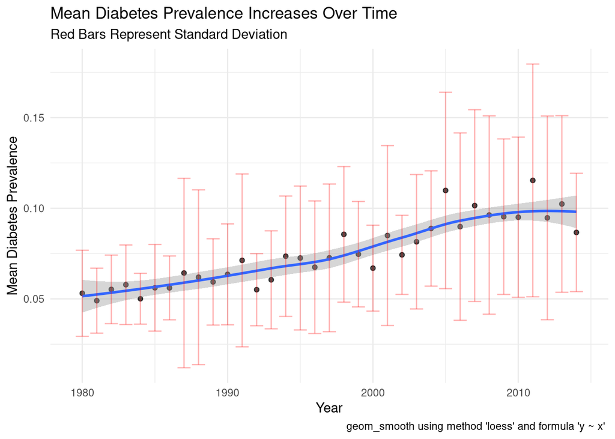

Figure 5.1: Mean Diabetes Prevalence from 1980 to 2014

```r
Figure_2 <- ggplot(data = data_summary, aes(x = Year, y = mean_diabetes)) +
  geom_point(alpha = 0.7) +
  xlab("Year") +
  ylab("Mean Diabetes Prevalence") +
  theme_minimal() +
  labs(title = "Mean Diabetes Prevalence Increases Over Time", subtitle = "Red Bars Represent Standard Deviation", caption = " geom_smooth using method 'loess' and formula 'y ~ x' ") +
  geom_smooth() +
  geom_errorbar(aes(ymin=mean_diabetes-sd_diabetes, ymax=mean_diabetes+sd_diabetes), colour="red", alpha=0.3)

Figure_2
```

- *There is a slight increase in mean diabetes prevalence from 1980 to 2014*
- *The standard deviation bars indicate a high dispersion of data*

## 5.2 Australian Diabetes Trends By Sex

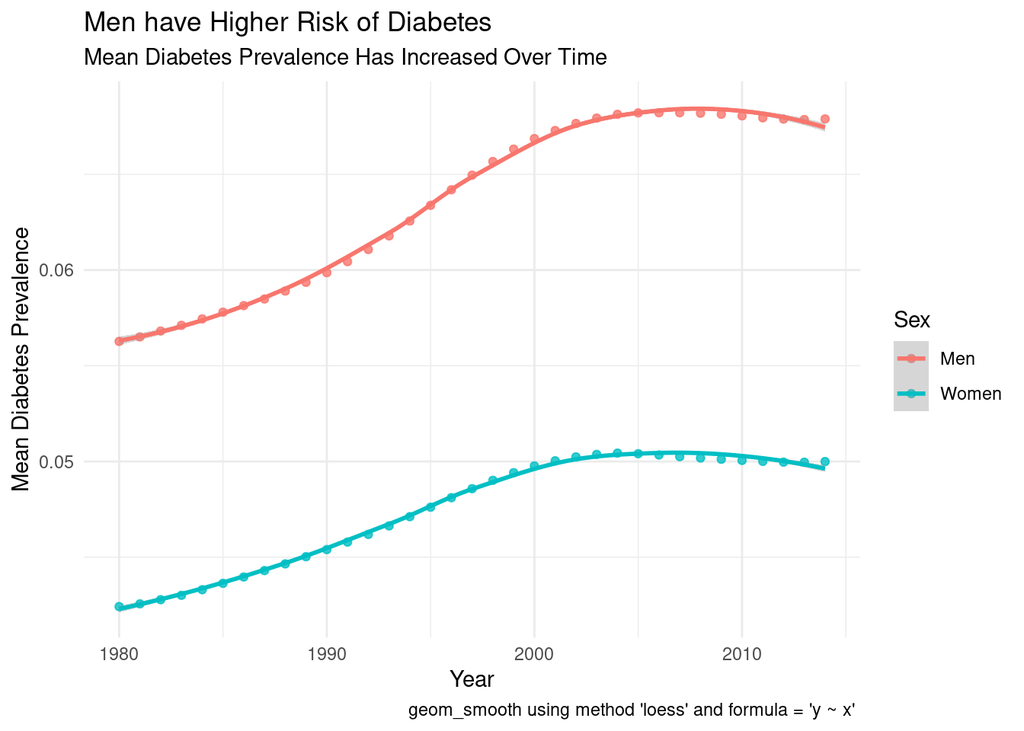

Figure 5.2: Australian Diabetes Prevalence from 1980-2014

```r
# first filter for australian data
Australia_summary <- data_full %>%
  filter(`Country/Region/World` == "Australia")

Figure_3 <- ggplot(data = Australia_summary, aes(x = Year, y = `Age-standardised diabetes prevalence`, col = Sex)) +
  geom_point(alpha = 0.8) +
  xlab("Year") +
  ylab("Mean Diabetes Prevalence") +
  labs(title = "Men have Higher Risk of Diabetes", subtitle = "Mean Diabetes Prevalence Has Increased Over Time", caption = "geom_smooth using method 'loess' and formula = 'y ~ x' ") +
  theme_minimal() +
  geom_smooth()

Figure_3
```

Figure 5.2 shows a trend of increasing mean diabates prevalence over time. Men have a noticeably higher mean than women. There is a steep increase from 1980 to 2000 and then a plateau. Data was only available up to 2014. It is unknown whether the plateua begins to trend downwards.

## 5.3 Mean Diabetes Prevalence by Country

```r
# group by country and rank means
data_country <- data_full %>%
  group_by(`Country/Region/World`) %>%
  summarise(mean_diabetes = mean(`Age-standardised diabetes prevalence`)) %>%
  arrange(desc(mean_diabetes))

# Create variable for first 10 rows
data_country_10 <- head(data_country,10)


# create table
kable(data_country_10,
             caption = "Top 10 Mean Diabetes Prevalence by Country",
             digits = 3,
      row_number(10))
```

Table 5.1: Top 10 Mean Diabetes Prevalence by Country

| Country/Region/World | mean_diabetes |
| --- | --- |
| Nauru | 0.287 |
| American Samoa | 0.274 |
| Cook Islands | 0.207 |
| Palau | 0.186 |
| Niue | 0.185 |
| Tokelau | 0.169 |
| Tuvalu | 0.168 |
| French Polynesia | 0.165 |
| Marshall Islands | 0.163 |
| Tonga | 0.162 |

# 6 Conclusions